# ECE 466 Homework 4

**Spring 22** **Due 2/3/2022**

- You have 10 extra points. I will carry your points over the other homeworks as well. So, if you score 105 in this homework, I will add 0.5 points to your total homework score for the whole semester.
- You can collaborate on homeworks and turn in a homework for 2 people. Make sure both of you submit.
- Include your codes and answers within the cells that are requested. Do not create additional cells.
- **Upload the `.ipynb` document and a generated `.html` in a zip:**

> You can use any modules you like for this question. I still need to see your code though. You can change the kernel for cells if you'd like to use another language.

**Your Name: [Name Surname]**

```python
import numpy as np
import matplotlib.pyplot as plt
from scipy import signal
```

#### 1:

[20] Write codes to compute and plot the **convolutions** of the following for 100 time points. Make sure you only show the results where they are legitimate, i.e. the input and the system are defined. For example, if you have a step input, you can't realize it in a computer as it is infinitely long. In that case, you should plot results where the input behaves like a unit step.

1. $h[n] = \left(\frac{1}{5}\right)^nu[n]$, $x[n] = u[n]-u[n-10]$.
2. $h[n] = \left(\frac{1}{2}\right)^nu[n]$, $x[n] = \left(\frac{1}{4}\right)^nu[n]$.
3. $h[n] = \left(0.7\right)^nu[n]$, $x[n] = \cos(0.1\pi n)u[n]$.
4. $$h[n] = \begin{cases} 1, \;0\leq n\leq 4 \\ 0, \; elsewhere \end{cases},$$ $$x[n] = \begin{cases} \frac{1}{3}n, \;0\leq n\leq 6 \\ 0, \; elsewhere \end{cases}$$

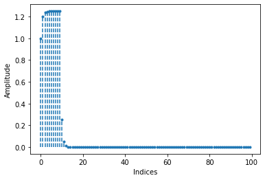

```python
# Your code for 1.1 should be written and executed in this cell.
n = np.arange(100, dtype=float)
x = np.zeros_like(n)
x[:10] = 1
h = 0.2**n
y = np.convolve(h, x)

plt.stem(y[:100], markerfmt='.', linefmt='--', basefmt=' ')
plt.xlabel('Indices')
plt.ylabel('Amplitude')
plt.show()
```

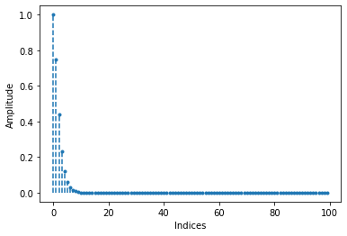

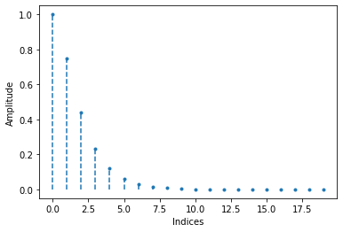

```
Y is: [1.         0.75       0.4375     0.234375   0.12109375 0.06152344
 0.03100586 0.01556396 0.00779724 0.00390244]
```

```python
# Your code for 1.2 should be written and executed in this cell.
x = 0.25**n
h = 0.5**n
y = np.convolve(h, x)

plt.stem(y[:100], markerfmt='.', linefmt='--', basefmt=' ')
plt.xlabel('Indices')
plt.ylabel('Amplitude')
plt.show()

plt.stem(y[:20], markerfmt='.', linefmt='--', basefmt=' ')
plt.xlabel('Indices')
plt.ylabel('Amplitude')
plt.show()

print('Y is: {}'.format(y[:10]))
```

**Answer for 1:**

Any value of $y[n]$ after 100 is not legitimate as at that point the computer will assume $h[100]=0$ while it is $h[100]=0.2^{100}.$

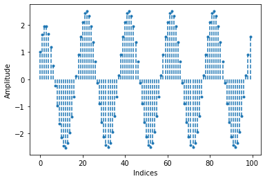

```python
# Your code for 1.3 should be written and executed in this cell.
x = np.cos(0.1*np.pi*n)
h = 0.7**n
y = np.convolve(h, x)

plt.stem(y[:100], markerfmt='.', linefmt='--', basefmt=' ')
plt.xlabel('Indices')
plt.ylabel('Amplitude')
plt.show()
```

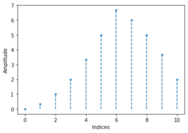

```python
# Your code for 1.4 should be written and executed in this cell.
x = 1/3*n[:7]
h = np.ones(5)
y = np.convolve(h, x)

plt.stem(y, markerfmt='.', linefmt='--', basefmt=' ')
plt.xlabel('Indices')
plt.ylabel('Amplitude')
plt.show()
```

#### 2:

[20 points] Consider a system represented by a linear constant coefficient difference equation given by $y[n] - 0.7y[n-1] +0.1y[n-2] = 2x[n] - x[n-2]$, with initial conditions $y[-1]=2$, $y[-2]=-1$ and input signal $x[n]=\cos(0.5\pi n)u[n]$. Code and plot the:

1. Impulse response of the system
2. ZSR
3. ZIR
4. Total response

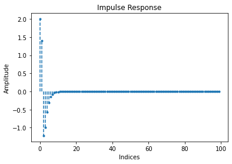

```python
# Your code for 2.1 should be written and executed in this cell.
b = [2, 0, -2]
a = [1, -0.7, 0.1]
lti_system = signal.dlti(b, a, dt=1)
_, h = signal.dimpulse(lti_system)
h = h[0].flatten()
plt.stem(h, linefmt='--', markerfmt='.',basefmt=' ')
plt.xlabel('Indices')
plt.ylabel('Amplitude')
plt.title('Impulse Response')
plt.show()
```

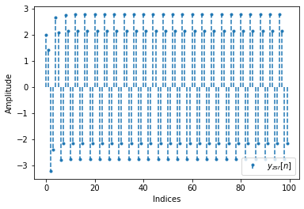

```python
# Your code for 2.2 should be written and executed in this cell.
x = np.cos(0.5*np.pi*n)
y_zsr = signal.lfilter(b, a, x)
plt.stem(y_zsr, label='$y_{zsr}[n]$', linefmt='--', markerfmt='.', basefmt=' ')
plt.xlabel('Indices')
plt.ylabel('Amplitude')
plt.legend(loc='lower right')
plt.show()
```

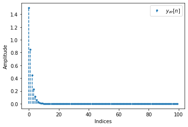

```python
# Your code for 2.3 should be written and executed in this cell.
x_zir = np.zeros(100, dtype=float)
ic = [2, -1]
zi = signal.lfiltic(b, a, ic)
y_zir, _ = signal.lfilter(b, a, x_zir, zi=zi)
plt.stem(y_zir, label='$y_{zir}[n]$', linefmt='--', markerfmt='.', basefmt=' ')
plt.xlabel('Indices')
plt.ylabel('Amplitude')
plt.legend()
plt.show()
```

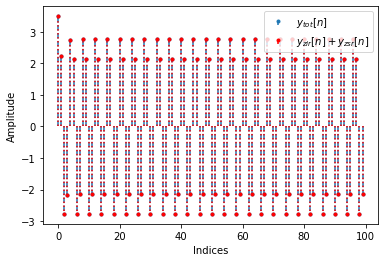

```python
# Your code for 2.4 should be written and executed in this cell.
y_tot, _ = signal.lfilter(b, a, x, zi=zi)
y_tot_2 = y_zsr+y_zir
plt.stem(y_tot, label='$y_{tot}[n]$', linefmt='--', markerfmt='.', basefmt=' ')
plt.stem(y_tot, label='$y_{zir}[n]+y_{zsr}[n]$', linefmt=':r', markerfmt='.r', basefmt=' ')
plt.xlabel('Indices')
plt.ylabel('Amplitude')
plt.legend(loc='upper right')
plt.show()
```

#### 3:

[30 points] Determine the causal signal $x[n]$ if its z-transform $X(z)$ is given by the following, and plot them. (**Use dlti and dimpulse**).

1. $X(z)=\frac{.2z}{z-2}$, ROC: $|z|<2$.
2. $X(z)=\frac{z^2+0.6z-0.5}{z^2-0.9z+0.2}$.
3. $X(z) = \frac{z^{-6}+z^{-7}}{1-z^{-1}}$
4. $X(z) = \frac{1}{4}\frac{1+6z^{-1}+z^{-2}}{(1-2z^{-1}+2z^{-2})(1-0.5z^{-1})}$
5. $X(z) = \frac{2-1.5z^{-1}}{1-1.5z^{-1}+0.5z^{-2}}$.
6. $X(z)$ is specified by the image below. $G=\frac{1}{4}$.

[figure not shown]

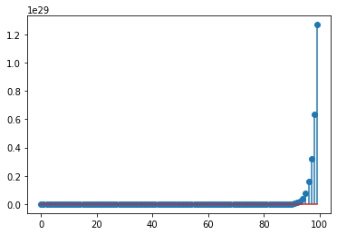

```
array([  0.2,   0.4,   0.8,   1.6,   3.2,   6.4,  12.8,  25.6,  51.2,
       102.4])
```

```python
# Your code for 3.1 should be written and executed in this cell.
sys_1 = signal.dlti([0], [2], .2, dt=1) # zeros, poles, gain
_, x = signal.dimpulse(sys_1)
x = x[0].flatten()
plt.stem(x)
plt.show()
x[:10]
```

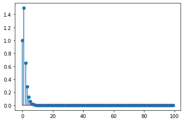

```
array([1.        , 1.5       , 0.65      , 0.285     , 0.1265    ,
       0.05685   , 0.025865  , 0.0119085 , 0.00554465, 0.00260849])
```

```python
# Your code for 3.2 should be written and executed in this cell.
sys_2 = signal.dlti([1, 0.6, -0.5], [1, -0.9, 0.2], dt=1) # transfer function coefficients
_, x = signal.dimpulse(sys_2)
x = x[0].flatten()
plt.stem(x)
plt.show()
x[:10]
```

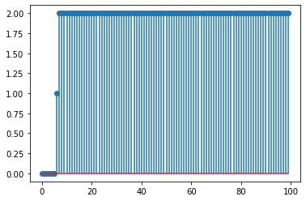

```
array([0., 0., 0., 0., 0., 0., 1., 2., 2., 2.])
```

```python
# Your code for 3.3 should be written and executed in this cell.
sys_3 = signal.dlti([1, 1], [1,-1,0,0,0,0,0,0], dt=1) # transfer function coefficients
_, x = signal.dimpulse(sys_3)
x = x[0].flatten()
plt.stem(x)
plt.show()
x[:10]
```

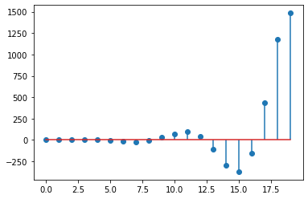

```
array([  0.25      ,   2.125     ,   4.8125    ,   5.90625   ,
         2.453125  ,  -6.7734375 , -18.38671875, -23.19335938,
        -9.59667969,  27.20166016])
```

```python
# Your code for 3.4 should be written and executed in this cell.
b = [1, 6, 1, 0] # denominator is of third degree, so we multiply top and bottom with z^3
a = np.polymul([1,-2,2],[1,-0.5])*4 # Find the polynomial coefficient of the denominator.
sys_4 = signal.dlti(b, a, dt=1) # transfer function
_, x = signal.dimpulse(sys_4)
x = x[0].flatten()
plt.stem(x[:20])
plt.show()
x[:10]
```

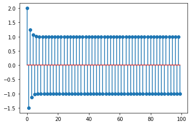

```
array([ 2.        , -1.5       ,  1.25      , -1.125     ,  1.0625    ,
       -1.03125   ,  1.015625  , -1.0078125 ,  1.00390625, -1.00195312])
```

```python
# Your code for 3.5 should be written and executed in this cell.
b = [2, 1.5, 0] # Denominator is of order 3.
a = [1, 1.5, 0.5]

sys_5 = signal.dlti(b, a, dt=1) # Transfer function
_, x = signal.dimpulse(sys_5)
x = x[0].flatten()
plt.stem(x)
plt.show()
x[:10]
```

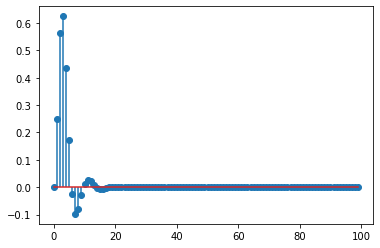

```
array([ 0.        ,  0.25      ,  0.5625    ,  0.625     ,  0.4375    ,
        0.171875  , -0.0234375 , -0.09765625, -0.08007812, -0.02832031])
```

```python
# Your code for 3.6 should be written and executed in this cell.

zeros = [-0.5, -0.25]
poles = [1/2+1/2*1j, 1/2-1/2*1j, 1/2]
gain = 1/4

sys_6 = signal.dlti(zeros, poles, gain, dt=1) # zeros, poles, gain
_, x = signal.dimpulse(sys_6)
x = x[0].flatten()
plt.stem(x)
plt.show()
x[:10]
```

#### 4:

[20 points] Compute and plot the response of the system $y[n] = 0.7y[n - 1] - 0.12y[n - 2] + x[n -1] + x[n - 2]$, to the input $x[n]=nu[n]$. Is the system stable?

```
C:\Users\emres\anaconda3\lib\site-packages\scipy\signal\filter_design.py:1631: BadCoefficients: Badly conditioned filter coefficients (numerator): the results may be meaningless
  warnings.warn("Badly conditioned filter coefficients (numerator): the "
```

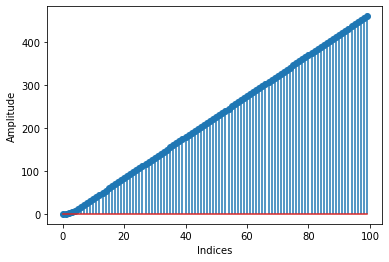

```
Zeros: [-1.]
Poles: [0.4 0.3]
Gain: 1.0
```

```python
# Your code for 4 should be written and executed in this cell.
b = [0, 1, 1]
a = [1, -0.7, 0.12]

z, p, g = signal.tf2zpk(b, a)

x = n
y = signal.lfilter(b, a, x)
plt.stem(y)
plt.xlabel('Indices')
plt.ylabel('Amplitude')
plt.show()
print('Zeros: {}'.format(z))
print('Poles: {}'.format(p))
print('Gain: {}'.format(g))
```

ROC includes the unit circle, so the system is stable.

#### 5:

[20 points] We want to design a causal discrete-time LTI system with the property that if the input is $$x[n] = \left(0.5\right)^nu[n]-\frac{1}{4}\left(0.5\right)^{n-1}u[n-1],$$ then the output is $$y[n] = \left(\frac{1}{3}\right)^nu[n].$$

1. Determine the poles, zeros and gain of the system. (**You can do this by hand or using `signal.tf2zpk`**)
2. Find and write the difference equation that characterizes this system.
3. Determine if the system is stable.
4. Plot the impulse response of the system.

**Answer 5.1:**

First, we need to evaluate $X(z)$ and $Y(z)$ to get $H(z)=\frac{Y(z)}{X(z)}$. $$X(z)= \frac{1}{1-0.5z^{-1}}-\frac{1}{4}\frac{z^{-1}}{1-0.5z^{-1}} = \frac{1-0.25z^{-1}}{1-0.5z^{-1}}$$

$$Y(z) = \frac{1}{1-\frac{1}{3}z^{-1}}$$

Then, $$H(z) = \frac{1}{1-\frac{1}{3}z^{-1}}\frac{1-0.5z^{-1}}{1-0.25z^{-1}}.$$

```python
# Your code for 5.1 should be written and executed in this cell.
b_x = [1, -0.25]
a_x = [1, -0.5]
b_y = [1, 0]
a_y = [1, -1/3]
num = np.polymul(b_y, a_x)
den = np.polymul(a_y, b_x)

print('Numerator coefficients are: {}'.format(num))
print('Denominator coefficients are: {}'.format(den))

z_h, p_h, g_h = signal.tf2zpk(num, den)
print('Zeros: {}'.format(z_h))
print('Poles: {}'.format(p_h))
print('Gain: {}'.format(g_h))
```

```
Numerator coefficients are: [ 1.  -0.5  0. ]
Denominator coefficients are: [ 1.         -0.58333333  0.08333333]
Zeros: [0.5 0. ]
Poles: [0.33333333 0.25      ]
Gain: 1.0
```

**Answers for 5:**

1. $$H(z) = \frac{z^2-\frac{1}{2}z}{z^2-\frac{7}{12}z+\frac{1}{12}}$$
2. Both poles are inside unit circle and the system is causal. Hence the system is stable.

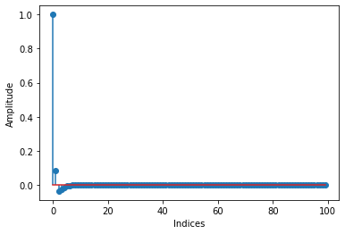

```python
# Your code for 5.4 should be written and executed in this cell.

_, h = signal.dimpulse((num,den,1))
h = h[0].flatten()

plt.stem(h)
plt.xlabel('Indices')
plt.ylabel('Amplitude')
plt.show()
```